# Assignment 6

Zixuan Ma

11/24/2016

#Addignment 6

In this assignment you will be looking at data from a MOOC. It contains the following per-student variables:

certified (yes/no) - Whether or not a student paid for the course  
forum.posts (numeric) - How many forum posts a student made throughout the course  
grade (numeric) - A student’s average grade for the course exam  
assignment (numeric) - A student’s average grade for the course assignments

##Part I

#Packages

```r
library(rpart)
```

#Data

```r
#Upload the data sets MOOC1.csv and MOOC2.csv
M1 <- read.csv("MOOC1.csv", header = TRUE)

M2 <- read.csv("MOOC2.csv", header = TRUE)
```

#Decision tree

```r
#Using the rpart package generate a classification tree predicting certified from the other variables in the M1 data frame. Which variables should you use?

#I would use grade and assignment variables
c.tree1 <- rpart(as.factor(certified) ~ grade + assignment,  method="class", data=M1)

#Check the results from the classifcation tree using the printcp() command
printcp(c.tree1)
```

```
##
## Classification tree:
## rpart(formula = as.factor(certified) ~ grade + assignment, data = M1,
##     method = "class")
##
## Variables actually used in tree construction:
## [1] assignment grade
##
## Root node error: 275/1000 = 0.275
##
## n= 1000
##
##         CP nsplit rel error   xerror      xstd
## 1 0.923636      0  1.000000 1.000000 0.0513455
## 2 0.058182      1  0.076364 0.076364 0.0164880
## 3 0.010000      2  0.018182 0.018182 0.0081108
```

```r
#Plot your tree
post(c.tree1, file = "tree1.ps", title = "MOOC") #This creates a pdf image of the tree
```

##Part II

#The heading “xerror” in the printcp table stands for “cross validation error”, it is the error rate of assigning students to certified/uncertified of the model averaged over 10-fold cross validation. CP stands for “Complexity Parameter” and represents the cost to error for adding a node to the tree. Notice it decreases as we add more nodes to the tree which implies that more nodes make better predictions. However, more nodes also mean that we may be making the model less generalizable, this is known as “overfitting”.

#If we are worried about overfitting we can remove nodes form our tree using the prune() command, setting cp to the CP value from the table that corresponds to the number of nodes we want the tree to terminate at. Let’s set it to two nodes.

```r
c.tree2 <- prune(c.tree1, cp = 0.058182)#Set cp to the level at which you want the tree to end

#Visualize this tree and compare it to the one you generated earlier

post(c.tree2, file = "tree2.ps", title = "MOOC") #This creates a pdf image of the tree
```

#Now use both the original tree and the pruned tree to make predictions about the the students in the second data set. Which tree has a lower error rate?

```r
M2$predict1 <- predict(c.tree1, M2, type = "class")

M2$predict2 <- predict(c.tree2, M2, type = "class")

table(M2$certified, M2$predict1)
```

```
##
##         no  yes
##   no  2056   24
##   yes 7790  130
```

```r
table(M2$certified, M2$predict2)
```

```
##
##         no  yes
##   no   896 1184
##   yes 3453 4467
```

```r
# The pruned tree has a lower error rate.
```

##Part III

Choose a data file from the (University of Michigan Open Data Set)[https://github.com/bkoester/PLA/tree/master/data]. Choose an outcome variable that you would like to predict. Build two models that predict that outcome from the other variables. The first model should use raw variables, the second should feature select or feature extract variables from the data. Which model is better according to the cross validation metrics?

```r
library(rpart)
library(dplyr)
#load the data
D1<-read.csv("student.course.csv",header = TRUE)
D2<-read.csv("student.record.csv",header = TRUE)
#I decided to use combine the data sets and view the vraibles together
D3<-left_join(D2,D1,by="ANONID")
#select the variables that I am interested in
D4<-select(D3,HSGPA,GRD_PTS_PER_UNIT,GPAO,TERM)
# I decided to use term and GPOA to predict grade point per unit.
model1<- rpart(GRD_PTS_PER_UNIT~ GPAO+TERM, data=D4)
printcp(model1)
```

```
##
## Regression tree:
## rpart(formula = GRD_PTS_PER_UNIT ~ GPAO + TERM, data = D4)
##
## Variables actually used in tree construction:
## [1] GPAO
##
## Root node error: 1200199/1327065 = 0.9044
##
## n=1327065 (11507 observations deleted due to missingness)
##
##         CP nsplit rel error  xerror      xstd
## 1 0.199996      0   1.00000 1.00000 0.0018315
## 2 0.036346      1   0.80000 0.80012 0.0015551
## 3 0.034488      2   0.76366 0.76371 0.0015133
## 4 0.010000      3   0.72917 0.72937 0.0014951
```

```r
#Using CPA to generate extract variable
as.numeric(D4$TERM)
```

[output not shown]

```r
D5 <- scale(na.omit(D4), center = TRUE)
pc <- prcomp(D5, scale = TRUE)
summary(pc)
```

```
## Importance of components:
##                           PC1    PC2    PC3    PC4
## Standard deviation     1.2556 1.0024 0.9669 0.6955
## Proportion of Variance 0.3941 0.2512 0.2337 0.1209
## Cumulative Proportion  0.3941 0.6453 0.8791 1.0000
```

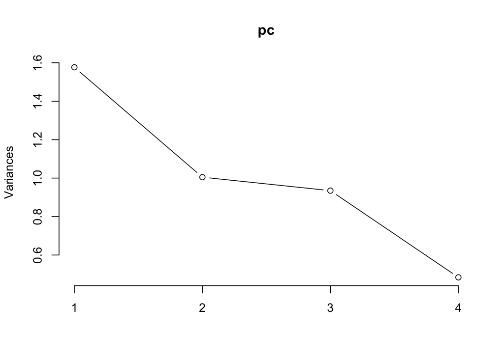

```r
plot(pc,type="l")
```

```r
# according to the result, i decided to keep PC1,PC2,PC3
pc1<-data.frame(pc[["x"]])
Dp<-cbind(na.omit(D4),pc1)
#fitting the new model with seleted variables
model2<-rpart(GRD_PTS_PER_UNIT~ PC1+PC2+PC3, data=Dp)
printcp(model2)
```

```
##
## Regression tree:
## rpart(formula = GRD_PTS_PER_UNIT ~ PC1 + PC2 + PC3, data = Dp)
##
## Variables actually used in tree construction:
## [1] PC1
##
## Root node error: 1164413/1309688 = 0.88908
##
## n= 1309688
##
##         CP nsplit rel error  xerror       xstd
## 1 0.478810      0   1.00000 1.00000 0.00180930
## 2 0.101883      1   0.52119 0.52133 0.00081817
## 3 0.093860      2   0.41931 0.41986 0.00079337
## 4 0.014242      3   0.32545 0.32568 0.00067821
## 5 0.011513      4   0.31120 0.31177 0.00066702
## 6 0.011333      5   0.29969 0.29877 0.00065624
## 7 0.010000      6   0.28836 0.28849 0.00063245
```

```r
#model2 has a smaller xerror, therefore, I prefer model2
```

### To Submit Your Assignment

Please submit your assignment by first “knitting” your RMarkdown document into an html file and then commit, push and pull request both the RMarkdown file and the html file.